# CountDataGLM_Practice

Timothee Bonnet

25 September 2020

```r
library(tidyverse)
library(ggbeeswarm)
library(janitor)
library(emmeans)
library(glmmTMB)
library(car)
library(DHARMa)
```

Noisy miners are birds native to south-east Australia. They form large breeding colonies in open woodlands, often at the edge between closed and open landscape and try to obtain monopoly on food resources by harassing, excluding and regularly killing all other small bird species. In native vegetation this is not a problem because there are few places appropriate for noisy miners colonies. However, in cities and farmland the vegetation structure has been modified in a way that most areas with trees are attractive to noisy miners. The over-abundance of noisy miners is a big problem for the conservation of some small woodland birds. A team at the Fenner School, ANU, tested whether removing a few noisy miners from a colony was sufficient to reduce the number of attacks on small birds, so that noisy miner removal could be used to protect critical populations of small birds.

On several farms, the researchers selected one treatment site where they removed a few individuals, and a control site (variable `Treatment`). They counted the number of small birds attacked by noisy miners during a fixed period of time (`Victims`). For the treatment to be interesting and applicable the effect of removal should last at least a few days, but it is possible that new noisy miners would enter the colony quickly after birds are removed. Therefore, researchers counted the number of victims during two periods: just after the removal (`Phase=0`) and one week later (`Phase=1`).

We have three questions:

1. Does the treatment have an immediate effect on the number of victims?
2. Does the treatment have a lasting effect?
3. Does the treatment work generally across farms, or is there evidence that it works better in some farms than other? (that question will be important if we decide to use the method to try and protect specific bird populations)

```r
miners <- read_csv("Harassment.Data.csv")
```

## Treatment

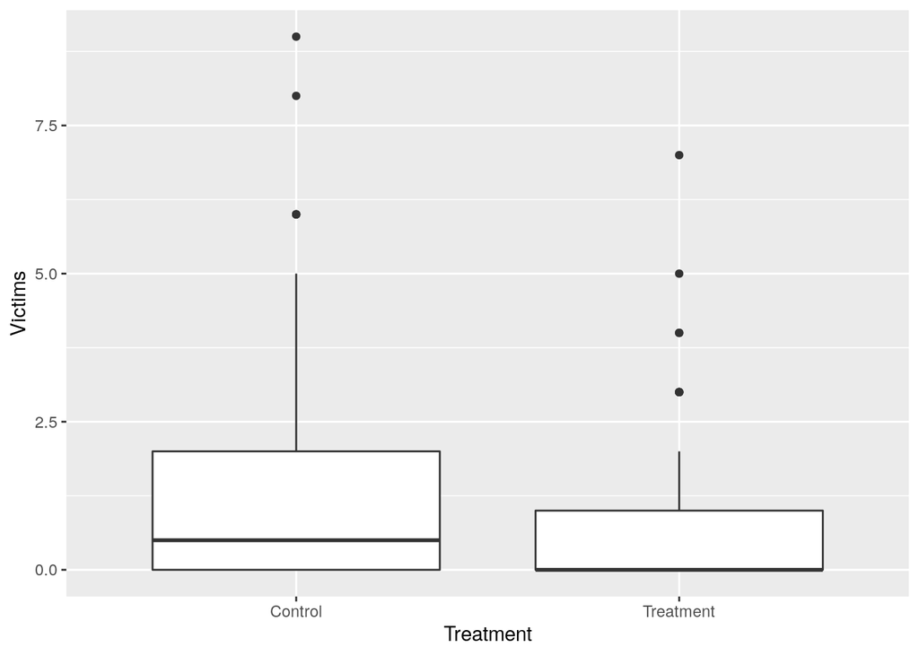

```r
ggplot(miners, aes(y=Victims, x=Treatment)) + geom_boxplot()
```

```r
summary(m_treatment <- glmmTMB(Victims ~ Treatment, data=miners, family = nbinom1()))
```

```
##  Family: nbinom1  ( log )
## Formula:          Victims ~ Treatment
## Data: miners
##
##      AIC      BIC   logLik deviance df.resid
##    702.8    713.4   -348.4    696.8      253
##
##
## Overdispersion parameter for nbinom1 family (): 1.33
##
## Conditional model:
##                    Estimate Std. Error z value Pr(>|z|)
## (Intercept)          0.1758     0.1189   1.478   0.1393
## TreatmentTreatment  -0.4187     0.1768  -2.368   0.0179 *
## ---
## Signif. codes:  0 '***' 0.001 '**' 0.01 '*' 0.05 '.' 0.1 ' ' 1
```

First, let's check that the model captures variation reasonably well.

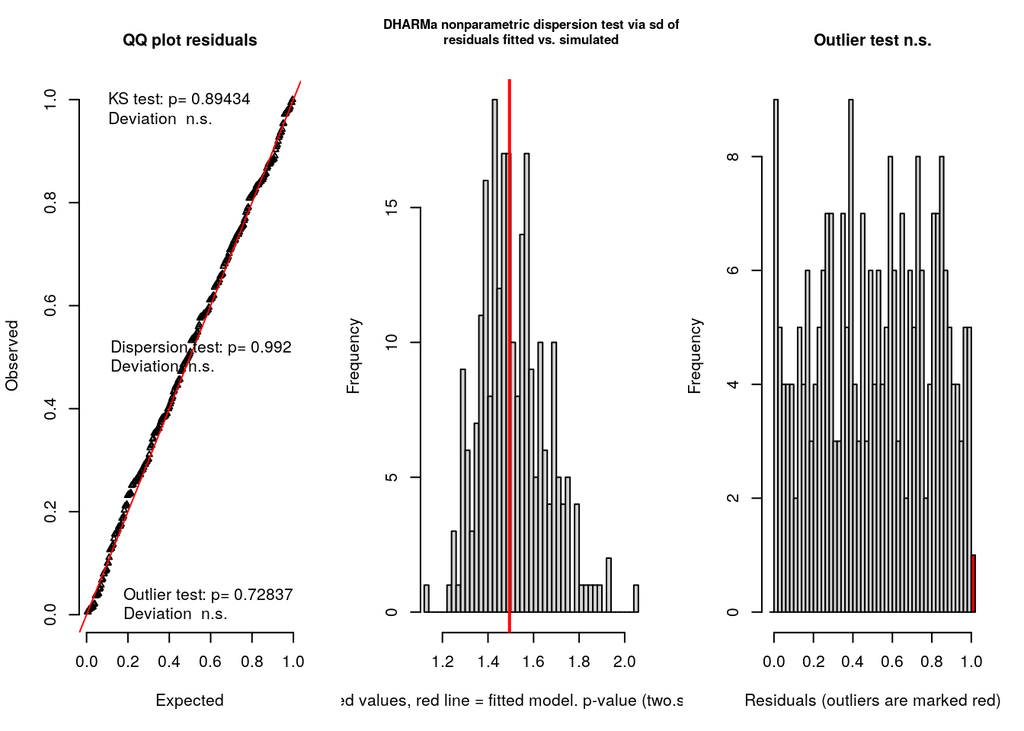

```
## $uniformity
##
##  One-sample Kolmogorov-Smirnov test
##
## data:  simulationOutput$scaledResiduals
## D = 0.036002, p-value = 0.8943
## alternative hypothesis: two-sided
##
##
## $dispersion
##
##  DHARMa nonparametric dispersion test via sd of residuals fitted vs.
##  simulated
##
## data:  simulationOutput
## ratioObsSim = 0.9879, p-value = 0.992
## alternative hypothesis: two.sided
##
##
## $outliers
##
##  DHARMa outlier test based on exact binomial test
##
## data:  simulationOutput
## outliers at both margin(s) = 1, simulations = 256, p-value = 0.7284
## alternative hypothesis: true probability of success is not equal to 0.007968127
## 95 percent confidence interval:
##  0.0000988928 0.0215708904
## sample estimates:
## frequency of outliers (expected: 0.00796812749003984 )
##                                             0.00390625
```

```
## $uniformity
##
##  One-sample Kolmogorov-Smirnov test
##
## data:  simulationOutput$scaledResiduals
## D = 0.036002, p-value = 0.8943
## alternative hypothesis: two-sided
##
##
## $dispersion
##
##  DHARMa nonparametric dispersion test via sd of residuals fitted vs.
##  simulated
##
## data:  simulationOutput
## ratioObsSim = 0.9879, p-value = 0.992
## alternative hypothesis: two.sided
##
##
## $outliers
##
##  DHARMa outlier test based on exact binomial test
##
## data:  simulationOutput
## outliers at both margin(s) = 1, simulations = 256, p-value = 0.7284
## alternative hypothesis: true probability of success is not equal to 0.007968127
## 95 percent confidence interval:
##  0.0000988928 0.0215708904
## sample estimates:
## frequency of outliers (expected: 0.00796812749003984 )
##                                             0.00390625
```

```r
testResiduals(m_treatment)
```

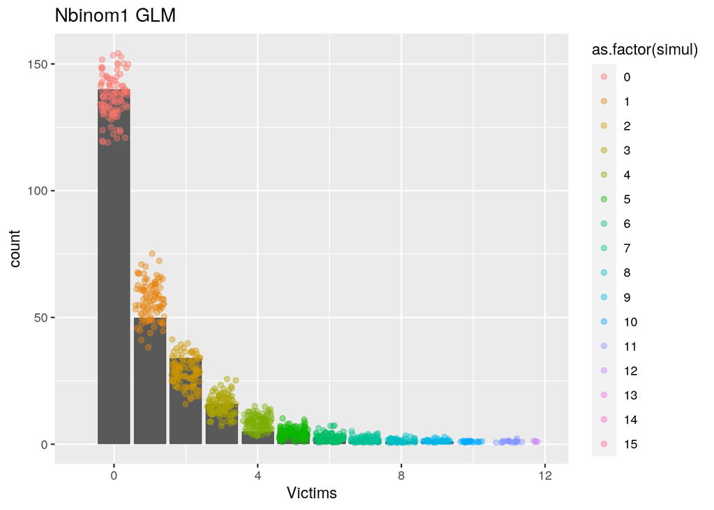

```r
fsimul <- function(x) {
  tibble(simul=simulate(m_treatment)) %>%
  tabyl(simul)
  }

tibbsimul2 <- map_dfr(.x = 1:100, .f = fsimul)

ggplot(miners, aes(x=Victims))+geom_bar() +
  geom_jitter(data = tibbsimul2,
             mapping = aes(x=simul, y=n, col=as.factor(simul)),
             alpha=0.4, inherit.aes = FALSE) + xlim(-1,12)+ ggtitle("Nbinom1 GLM")
```

It looks pretty good.

```r
Anova(m_treatment, type = 3)
```

```
## Analysis of Deviance Table (Type III Wald chisquare tests)
##
## Response: Victims
##              Chisq Df Pr(>Chisq)
## (Intercept) 2.1855  1    0.13931
## Treatment   5.6068  1    0.01789 *
## ---
## Signif. codes:  0 '***' 0.001 '**' 0.01 '*' 0.05 '.' 0.1 ' ' 1
```

```r
emmeans(m_treatment, pairwise~ Treatment, type="response")
```

```
## $emmeans
##  Treatment response    SE  df lower.CL upper.CL
##  Control      1.192 0.142 253    0.943     1.51
##  Treatment    0.784 0.113 253    0.591     1.04
##
## Confidence level used: 0.95
## Intervals are back-transformed from the log scale
##
## $contrasts
##  contrast            ratio    SE  df t.ratio p.value
##  Control / Treatment  1.52 0.269 253 2.368   0.0186
##
## Tests are performed on the log scale
```

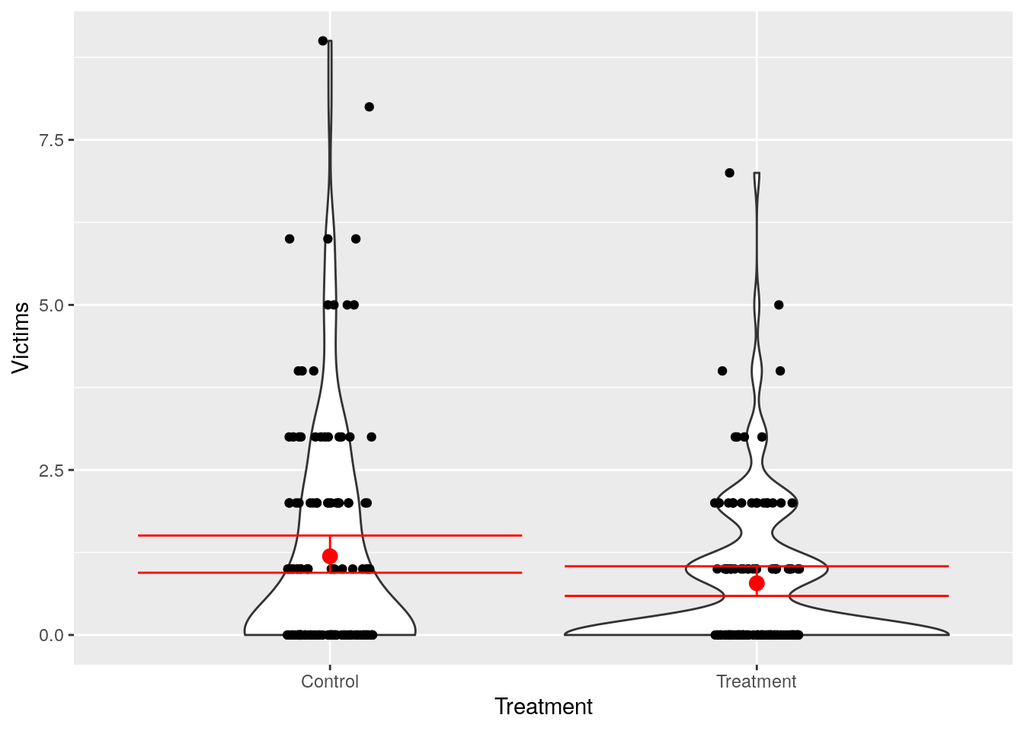

```r
emm_treatment <- as_tibble(emmeans(m_treatment, ~ Treatment, type="response"))

ggplot(miners, aes(y=Victims, x=Treatment)) + geom_violin() +
  geom_jitter(width = 0.1, height = 0) +
  geom_point(data=emm_treatment, aes(y=response), col="red", size=3) +
  geom_errorbar(data=emm_treatment, aes(x= Treatment, ymin=lower.CL, ymax=upper.CL),
                col="red", inherit.aes = FALSE)
```

## Treatment and phase

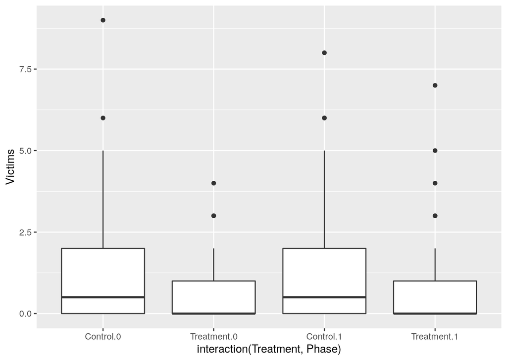

```r
ggplot(miners, aes(y=Victims, x=interaction(Treatment, Phase))) + geom_boxplot()
```

```r
summary(m_treatment_phase <- glmmTMB(Victims ~ Treatment*Phase, data=miners, family = nbinom1()))
```

```
##  Family: nbinom1  ( log )
## Formula:          Victims ~ Treatment * Phase
## Data: miners
##
##      AIC      BIC   logLik deviance df.resid
##    705.8    723.6   -347.9    695.8      251
##
##
## Overdispersion parameter for nbinom1 family (): 1.32
##
## Conditional model:
##                          Estimate Std. Error z value Pr(>|z|)
## (Intercept)               0.13674    0.16688   0.819   0.4126
## TreatmentTreatment       -0.50627    0.25763  -1.965   0.0494 *
## Phase                     0.07519    0.22811   0.330   0.7417
## TreatmentTreatment:Phase  0.16592    0.35216   0.471   0.6375
## ---
## Signif. codes:  0 '***' 0.001 '**' 0.01 '*' 0.05 '.' 0.1 ' ' 1
```

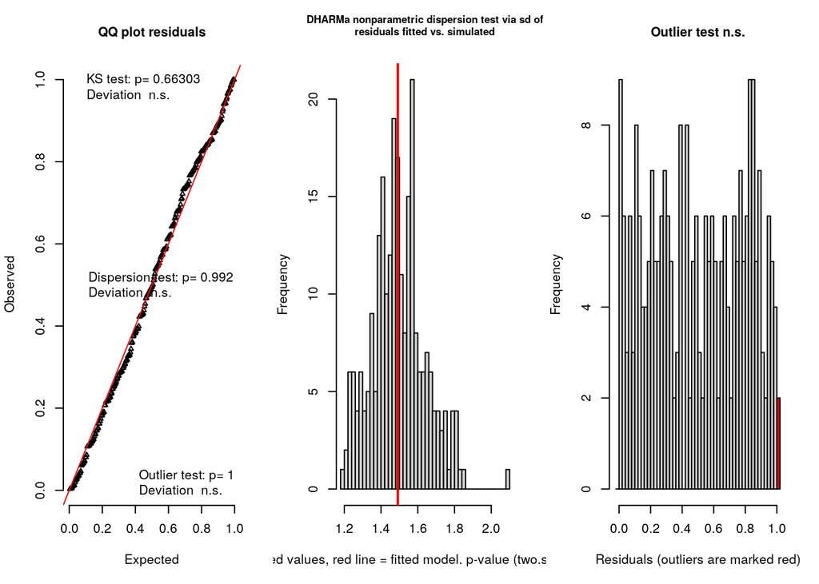

```
## $uniformity
##
##  One-sample Kolmogorov-Smirnov test
##
## data:  simulationOutput$scaledResiduals
## D = 0.045546, p-value = 0.663
## alternative hypothesis: two-sided
##
##
## $dispersion
##
##  DHARMa nonparametric dispersion test via sd of residuals fitted vs.
##  simulated
##
## data:  simulationOutput
## ratioObsSim = 0.99557, p-value = 0.992
## alternative hypothesis: two.sided
##
##
## $outliers
##
##  DHARMa outlier test based on exact binomial test
##
## data:  simulationOutput
## outliers at both margin(s) = 2, simulations = 256, p-value = 1
## alternative hypothesis: true probability of success is not equal to 0.007968127
## 95 percent confidence interval:
##  0.0009475343 0.0279349142
## sample estimates:
## frequency of outliers (expected: 0.00796812749003984 )
##                                              0.0078125
```

```
## $uniformity
##
##  One-sample Kolmogorov-Smirnov test
##
## data:  simulationOutput$scaledResiduals
## D = 0.045546, p-value = 0.663
## alternative hypothesis: two-sided
##
##
## $dispersion
##
##  DHARMa nonparametric dispersion test via sd of residuals fitted vs.
##  simulated
##
## data:  simulationOutput
## ratioObsSim = 0.99557, p-value = 0.992
## alternative hypothesis: two.sided
##
##
## $outliers
##
##  DHARMa outlier test based on exact binomial test
##
## data:  simulationOutput
## outliers at both margin(s) = 2, simulations = 256, p-value = 1
## alternative hypothesis: true probability of success is not equal to 0.007968127
## 95 percent confidence interval:
##  0.0009475343 0.0279349142
## sample estimates:
## frequency of outliers (expected: 0.00796812749003984 )
##                                              0.0078125
```

```r
testResiduals(m_treatment_phase)
```

```r
Anova(m_treatment_phase, type = 3)
```

```
## Analysis of Deviance Table (Type III Wald chisquare tests)
##
## Response: Victims
##                  Chisq Df Pr(>Chisq)
## (Intercept)     0.6713  1    0.41258
## Treatment       3.8615  1    0.04941 *
## Phase           0.1086  1    0.74169
## Treatment:Phase 0.2220  1    0.63753
## ---
## Signif. codes:  0 '***' 0.001 '**' 0.01 '*' 0.05 '.' 0.1 ' ' 1
```

```r
emmeans(m_treatment_phase, pairwise~ Treatment*Phase, type="response")
```

```
## $emmeans
##  Treatment Phase response    SE  df lower.CL upper.CL
##  Control       0    1.147 0.191 251    0.825     1.59
##  Treatment     0    0.691 0.143 251    0.460     1.04
##  Control       1    1.236 0.201 251    0.898     1.70
##  Treatment     1    0.879 0.164 251    0.609     1.27
##
## Confidence level used: 0.95
## Intervals are back-transformed from the log scale
##
## $contrasts
##  contrast                  ratio    SE  df t.ratio p.value
##  Control 0 / Treatment 0   1.659 0.427 251  1.965  0.2041
##  Control 0 / Control 1     0.928 0.212 251 -0.330  0.9876
##  Control 0 / Treatment 1   1.304 0.317 251  1.090  0.6961
##  Treatment 0 / Control 1   0.559 0.143 251 -2.270  0.1080
##  Treatment 0 / Treatment 1 0.786 0.211 251 -0.898  0.8059
##  Control 1 / Treatment 1   1.405 0.339 251  1.409  0.4948
##
## P value adjustment: tukey method for comparing a family of 4 estimates
## Tests are performed on the log scale
```

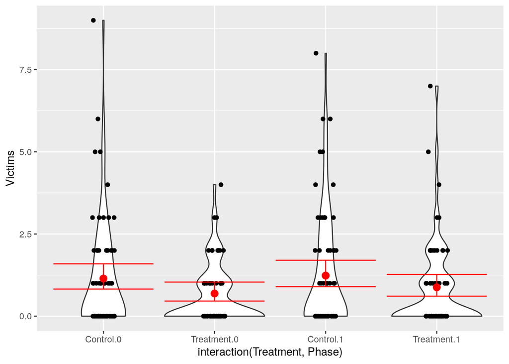

```r
emm_treatment_phase <- as_tibble(emmeans(m_treatment_phase, ~ Treatment*Phase, type="response"))

ggplot(miners, aes(y=Victims, x=interaction(Treatment, Phase))) + geom_violin() +
  geom_jitter(width = 0.1, height = 0) +
  geom_point(data=emm_treatment_phase, aes(y=response), col="red", size=3) +
  geom_errorbar(data=emm_treatment_phase,
                aes(x= interaction(Treatment, Phase), ymin=lower.CL, ymax=upper.CL),
                col="red", inherit.aes = FALSE)
```

We do not see much evidence for an effect of phase. That is good news.

Now, if Phase=1 corresponds to one week after treatment, if we assume that the return of noisy miners is linear with time what is our best guess for the time it would take to cancel the effect of treatment?

```r
-fixef(m_treatment_phase)$cond[2]/(fixef(m_treatment_phase)$cond[3]+fixef(m_treatment_phase)$cond[4])
```

```
## TreatmentTreatment
##           2.099766
```

Just 2 weeks! So, although we don't really have evidence for an effect of Phase, we may have to be careful about the efficacy of the treatment in time.

### Farms

You can decide to drop "Phase" from models, at least in a first time, to simplify a bit the plots and models.

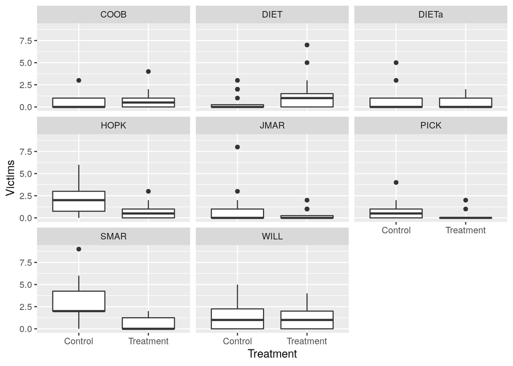

```r
ggplot(miners, aes(y=Victims, x=Treatment)) + geom_boxplot() + facet_wrap(~Farm)
```

```r
summary(m_farms <- glmmTMB(Victims ~ Treatment*Farm, data=miners, family = nbinom1()))
```

```
##  Family: nbinom1  ( log )
## Formula:          Victims ~ Treatment * Farm
## Data: miners
##
##      AIC      BIC   logLik deviance df.resid
##    674.9    735.2   -320.5    640.9      239
##
##
## Overdispersion parameter for nbinom1 family (): 0.827
##
## Conditional model:
##                              Estimate Std. Error z value Pr(>|z|)
## (Intercept)                   -0.7348     0.4421  -1.662  0.09649 .
## TreatmentTreatment             0.5954     0.5517   1.079  0.28052
## FarmDIET                      -0.0582     0.6477  -0.090  0.92841
## FarmDIETa                      0.3405     0.5863   0.581  0.56143
## FarmHOPK                       1.5036     0.4934   3.048  0.00231 **
## FarmJMAR                       0.3092     0.6046   0.511  0.60911
## FarmPICK                       0.5954     0.5517   1.079  0.28053
## FarmSMAR                       1.8913     0.4772   3.963 7.39e-05 ***
## FarmWILL                       1.0381     0.5221   1.988  0.04677 *
## TreatmentTreatment:FarmDIET    0.4386     0.7848   0.559  0.57626
## TreatmentTreatment:FarmDIETa  -0.9085     0.8032  -1.131  0.25798
## TreatmentTreatment:FarmHOPK   -1.5895     0.6870  -2.314  0.02069 *
## TreatmentTreatment:FarmJMAR   -1.1652     0.8502  -1.370  0.17053
## TreatmentTreatment:FarmPICK   -2.1306     0.9528  -2.236  0.02534 *
## TreatmentTreatment:FarmSMAR   -2.1555     0.6972  -3.092  0.00199 **
## TreatmentTreatment:FarmWILL   -0.6097     0.6777  -0.900  0.36827
## ---
## Signif. codes:  0 '***' 0.001 '**' 0.01 '*' 0.05 '.' 0.1 ' ' 1
```

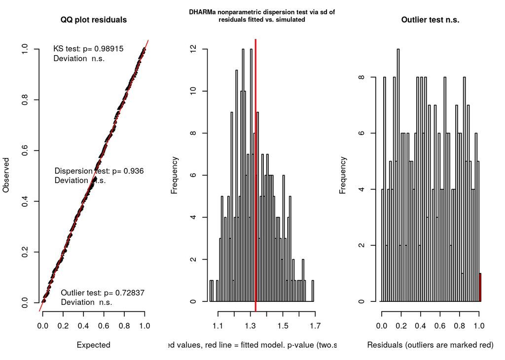

```
## $uniformity
##
##  One-sample Kolmogorov-Smirnov test
##
## data:  simulationOutput$scaledResiduals
## D = 0.027758, p-value = 0.9892
## alternative hypothesis: two-sided
##
##
## $dispersion
##
##  DHARMa nonparametric dispersion test via sd of residuals fitted vs.
##  simulated
##
## data:  simulationOutput
## ratioObsSim = 0.99855, p-value = 0.936
## alternative hypothesis: two.sided
##
##
## $outliers
##
##  DHARMa outlier test based on exact binomial test
##
## data:  simulationOutput
## outliers at both margin(s) = 1, simulations = 256, p-value = 0.7284
## alternative hypothesis: true probability of success is not equal to 0.007968127
## 95 percent confidence interval:
##  0.0000988928 0.0215708904
## sample estimates:
## frequency of outliers (expected: 0.00796812749003984 )
##                                             0.00390625
```

```
## $uniformity
##
##  One-sample Kolmogorov-Smirnov test
##
## data:  simulationOutput$scaledResiduals
## D = 0.027758, p-value = 0.9892
## alternative hypothesis: two-sided
##
##
## $dispersion
##
##  DHARMa nonparametric dispersion test via sd of residuals fitted vs.
##  simulated
##
## data:  simulationOutput
## ratioObsSim = 0.99855, p-value = 0.936
## alternative hypothesis: two.sided
##
##
## $outliers
##
##  DHARMa outlier test based on exact binomial test
##
## data:  simulationOutput
## outliers at both margin(s) = 1, simulations = 256, p-value = 0.7284
## alternative hypothesis: true probability of success is not equal to 0.007968127
## 95 percent confidence interval:
##  0.0000988928 0.0215708904
## sample estimates:
## frequency of outliers (expected: 0.00796812749003984 )
##                                             0.00390625
```

```r
testResiduals(m_farms)
```

```r
Anova(m_farms, type = 3)
```

```
## Analysis of Deviance Table (Type III Wald chisquare tests)
##
## Response: Victims
##                  Chisq Df Pr(>Chisq)
## (Intercept)     2.7626  1   0.096490 .
## Treatment       1.1646  1   0.280519
## Farm           43.4030  7  2.788e-07 ***
## Treatment:Farm 22.4240  7   0.002146 **
## ---
## Signif. codes:  0 '***' 0.001 '**' 0.01 '*' 0.05 '.' 0.1 ' ' 1
```

```r
emmeans(m_farms, pairwise~ Treatment, type="response")
```

```
## NOTE: Results may be misleading due to involvement in interactions
```

```
## $emmeans
##  Treatment response     SE  df lower.CL upper.CL
##  Control      0.968 0.1244 239    0.752    1.247
##  Treatment    0.636 0.0997 239    0.467    0.866
##
## Results are averaged over the levels of: Farm
## Confidence level used: 0.95
## Intervals are back-transformed from the log scale
##
## $contrasts
##  contrast            ratio  SE  df t.ratio p.value
##  Control / Treatment  1.52 0.3 239 2.128   0.0344
##
## Results are averaged over the levels of: Farm
## Tests are performed on the log scale
```

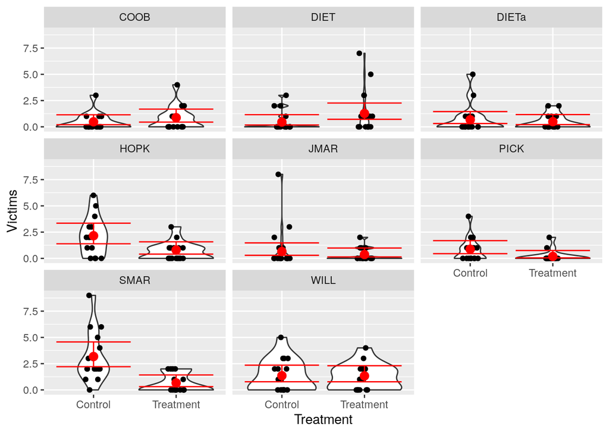

```r
emm_Farm <- as_tibble(emmeans(m_farms, ~ Treatment*Farm, type="response"))

ggplot(miners, aes(y=Victims, x=Treatment)) + geom_violin() +
  geom_jitter(width = 0.1, height = 0) +
  geom_point(data=emm_Farm, aes(y=response), col="red", size=3) +
  geom_errorbar(data=emm_Farm,
                aes(x= Treatment, ymin=lower.CL, ymax=upper.CL),
                col="red", inherit.aes = FALSE) + facet_wrap(~Farm)
```

Discuss how good the treatment is likely to be in practice.